# **Assignment 01 - Group 3**

Daniel + Megan + Mike

26 October 2021

# research question

How well does a census tract’s percentage of single-family homes and location relative to metropolitan center predict the average home value and tenure period in homes for the Commonwealth of Massachusetts?

# prior research

While the correlation between diversity of housing types and racial and economic diversity in neighborhoods have previously been established, this study investigated a potential relationship between housing typology and foreclosures. In fact, they found a positive (but varied) correlation between type and stability—neighborhoods with a range of housing stock had lower foreclosure and sales rates (Chakraborty et al 2018). Additionally, hedonic modelling of home values have been shown to respond to distance to city center. Longer distance from the metropolitan center correlates with lower property values in the magnitude of 1.82%. However, this relationship is highly income dependent, where devaluation associated with distance is higher for low-income individuals than for high-income individuals (Kestens et al. 2006).

- Chakraborty, Arnab and McMillan, Andrew, “Is Housing Diversity Good for Community Stability?: Evidence from the Housing Crisis,” *Journal of Planning Education and Research*, (2018), https://journals.sagepub.com/doi/10.1177/0739456X18810787
- Kestens, Yan, Theriault, Marius, and Des Rosiers Francois “Heterogeneity in hedonic modelling of house prices: looking at buyers’ household profiles,” *Journal of Geographical Systems*, (2006), https://link.springer.com/article/10.1007/s10109-005-0011-8

# data

The sample population for this study is the full set of all census tracts in the Commonwealth of Massachusetts.

The analysis will include the following variables:

CONTINUOUS

- Percentage of Single, Detached Housing Units (United States Census Bureau 2019)
- Geographic Mobility (percent of People Who Moved in During the Past Year) (United States Census Bureau 2019)
- Average value of Single, Detached Housing Units (United States Census Bureau 2019)

CATEGORICAL

- Majority White or Not Majority White Population (United States Census Bureau 2020)
- Urban Rural Classification (National Center for Health Statistics 2013)

## data table

The dataset includes 1478 census tracks. Note - the housing value is only available for 337 out of your 1478 census tracts, so we have filtered the data to only include those, which substantially reduces the sample size.

| GEOID | pct_sf_home | pct_moved | avg_sf_home_val | maj_white | GEOID_county | type |
| --- | --- | --- | --- | --- | --- | --- |
| 25027732302 | 0.2649573 | 0.2962963 | 140626.9 | TRUE | 25027 | Medium metro |
| 25001010100 | 0.3952991 | 0.0741453 | 366285.4 | TRUE | 25001 | Small metro |
| 25001015200 | 0.8540233 | 0.0332037 | 199807.0 | TRUE | 25001 | Small metro |
| 25001014700 | 0.8324324 | 0.1147854 | 185064.2 | TRUE | 25001 | Small metro |
| 25017337101 | 0.6613516 | 0.0842825 | 447660.2 | TRUE | 25017 | Large fringe metro |
| 25023504101 | 0.8820850 | 0.2869433 | 532236.4 | TRUE | 25023 | Large fringe metro |

# descriptive statistics

## continuous variables

The continuous variables we use are: 1) percentage of single, detached housing units, 2) geographic mobility, 3) average value of single, detached housing units.

```r
cont_summary <- tibble(
  variable = c("Percent of Single, Detached Housing Units",
               "Percent of Residents Who Arrived in Past Year",
               "Average Home Value for Single, Detached Housing Units"),

  `sample mean` = c(pct_moved_t_test$estimate,
                    pct_sf_home_t_test$estimate,
                    avg_sf_home_val_t_test$estimate),

  `population mean (95% confidence) - low` =
    c(pct_moved_t_test$conf.int[1],
      pct_sf_home_t_test$conf.int[1],
       avg_sf_home_val_t_test$conf.int[1]),

  `population mean (95% confidence) - high` =
    c(pct_moved_t_test$conf.int[2],
      pct_sf_home_t_test$conf.int[2],
      avg_sf_home_val_t_test$conf.int[2]),

  median = c(pct_moved_quartiles[3],
             pct_sf_home_quartiles[3],
             avg_sf_home_val_quartiles[3]),

  `interquartile range` = c(pct_moved_quartiles[4] - pct_moved_quartiles[2],
                            pct_sf_home_quartiles[4] - pct_sf_home_quartiles[2],
                            avg_sf_home_val_quartiles[4] - avg_sf_home_val_quartiles[2]),

  `standard deviation` = c(pct_moved_st_dev,
                          pct_sf_home_st_dev,
                          avg_sf_home_val_st_dev))

kable(cont_summary, digits = 0)
```

[output not shown]

## categorical Variables

The categorical variables we use are: 1) Majority White or Non-Majority White Classification of Census Tract and 2) Urban-Rural Classification

### census tracts with a majority white population

| Racial Composition of Census Tract | Sample Proportion | 95-percent confidence - low | 95-percent confidence - high |
| --- | --- | --- | --- |
| Majority White | 91 | 88 | 94 |
| Majority Non-White | 9 | 6 | 12 |

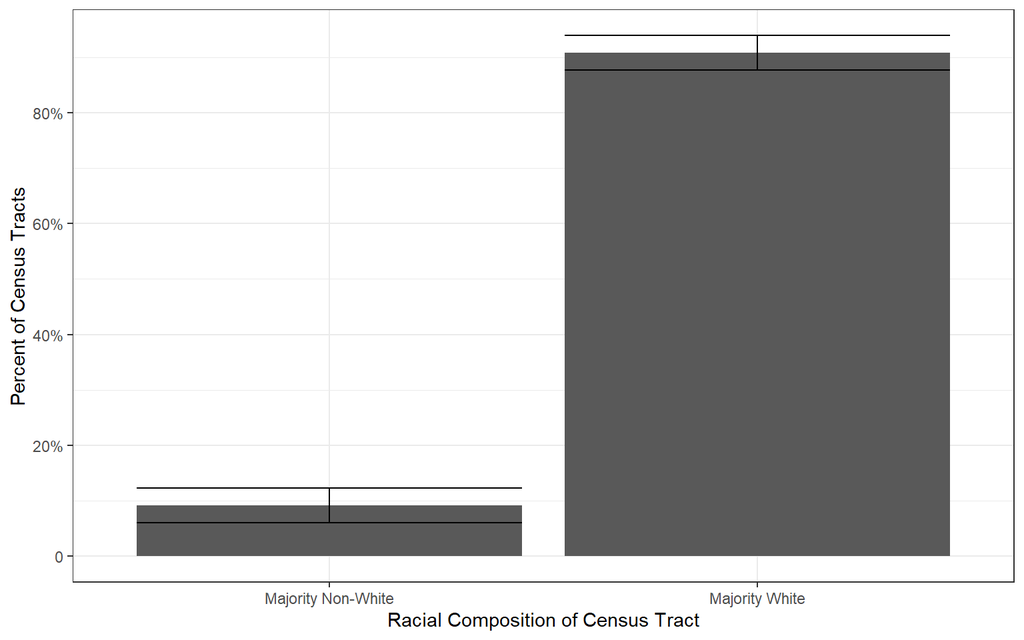

### urban-rural classifications

| County type | Sample proportion | 95-percent confidence - low | 95-percent confidence - high |
| --- | --- | --- | --- |
| Larch central metro | 19 | 15 | 24 |
| Large fringe metro | 64 | 59 | 69 |
| Medium metro | 12 | 9 | 16 |
| Small metro | 3 | 1 | 5 |
| Micropolitan | 1 | 0 | 2 |
| Non-core | 0 | NaN | NaN |

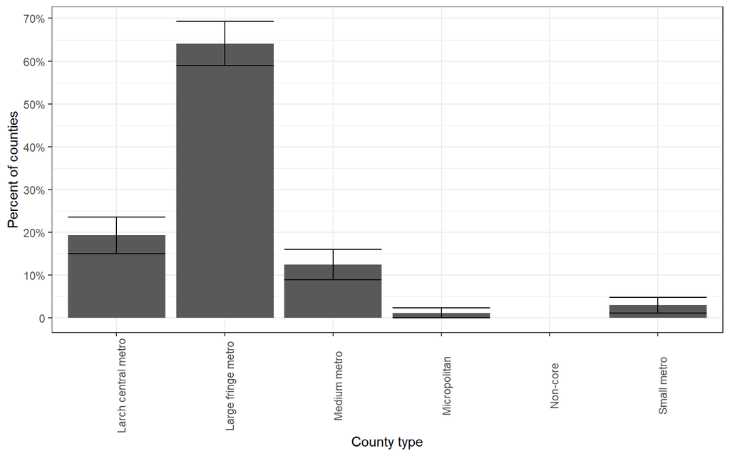